# Projekt 1

Estera Saidło

11 listopada 2018

## **1. Moc testów normalności**

### 1.1 Wstęp i przedstawienie danych

Założenie o rozkładzie normalnym zmiennych jest podstawą wielu klasycznych technik modelowania, między innymi analizy wariancji. Dlatego zgłębianie technik testowania tego założenia jest tak popularne.  
Przedmiotem badania jest poddanie analizie 6 testów zgodności pochodzących z różnych grup, które różnią się sposobem konstrukcji statystyki testowej i zbadanie, dla którego z 3 wybranych rozkładów(t-Studenta, wykładniczy, jednostajny) są najefektywniejsze.  
Przed rozpoczęciem analizy warto przyjrzeć się specyfikacji testów poddawanych analizie.

1. **test Shapiro-Wilka** - jest uważany za najlepszy test do badania normalności rozkładu ze wzgledu na jego dużą moc i możliwość użycia przy niewielkiej próbie. Ten test bazuje na spostrzeżeniu, iż analizując dopasowanie próbnego zbioru danych do rozkładu normalnego jest podobne do zadania liniowej regresji.

2. **test Jarque-Bera** - jest testem opartym o momenty z próby. Wykorzystuje specyficzną właściwość rozkładu normalnego, tzn. skośność = 0 i kurtozę = 3. Niestety przy niewielkich próbach test traci na niedokładnym oszcowaniu wartości krytycznych.

3. **test Pearsona** - jest to test oparty o statystykę chi-kwadrat, która dla prawdziwej H0 ma asymptotyczny rozkład chi-kwadrat. Przybliżenie rozkładem asymptotycznym ma sens, gdy obserwowana liczebność obserwacji w klasie jest co najmniej 10.

4. **test Andersona-Darlinga** - jest to test, który bada zgodność z rozkładem normalnym przez ocenę odległości pomiędzy dystrybuantą empiryczną a dystrybuantą rozkładu normalnego. Ma większą czułość w “ogonach” testowanego rozkładu.

5. **test Lillieforsa** - tak jak test Andersona-Darlinga opiera się na odległościach pomiędzy dystrybuantami. Jest ulepszoną wersją testu Kołmogorowa-Smirnowa, gdyż w przeciwieństwie do niego pozwala na badanie zgodności z rodziną rozkładów normalnych, bez znajomości parametrów średniej i odchylenia standardowego.

6. **test SJ** - jest to test oparty o statystykę SJ(S od “standard deviation”" i J od “average absolute deviation from the median”). Jest testem kierunkowym, badajacym ciężko-ogonowość rozkładu.

W celu postawienia hipotez dotyczących mocy testów, warto przyjrzeć się wykresom gęstości poszczególnych rozkładów dla poszczególnych długości próby.

#### **gęstości rozkładu t-Studenta**

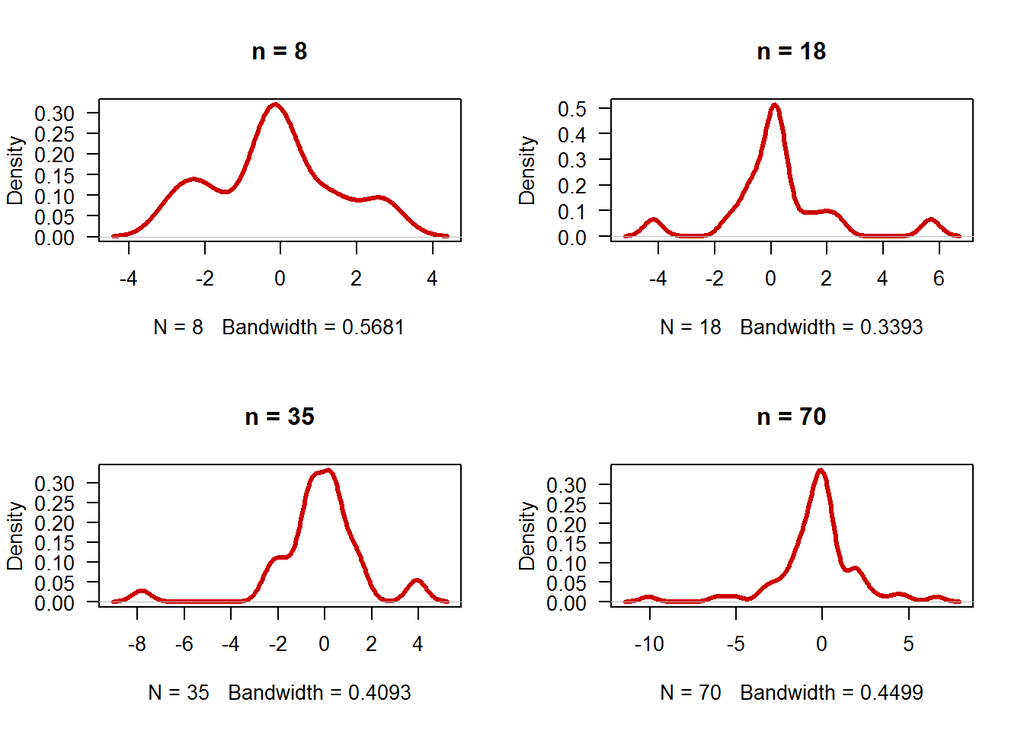

#### **gęstości rozkładu jednostajnego**

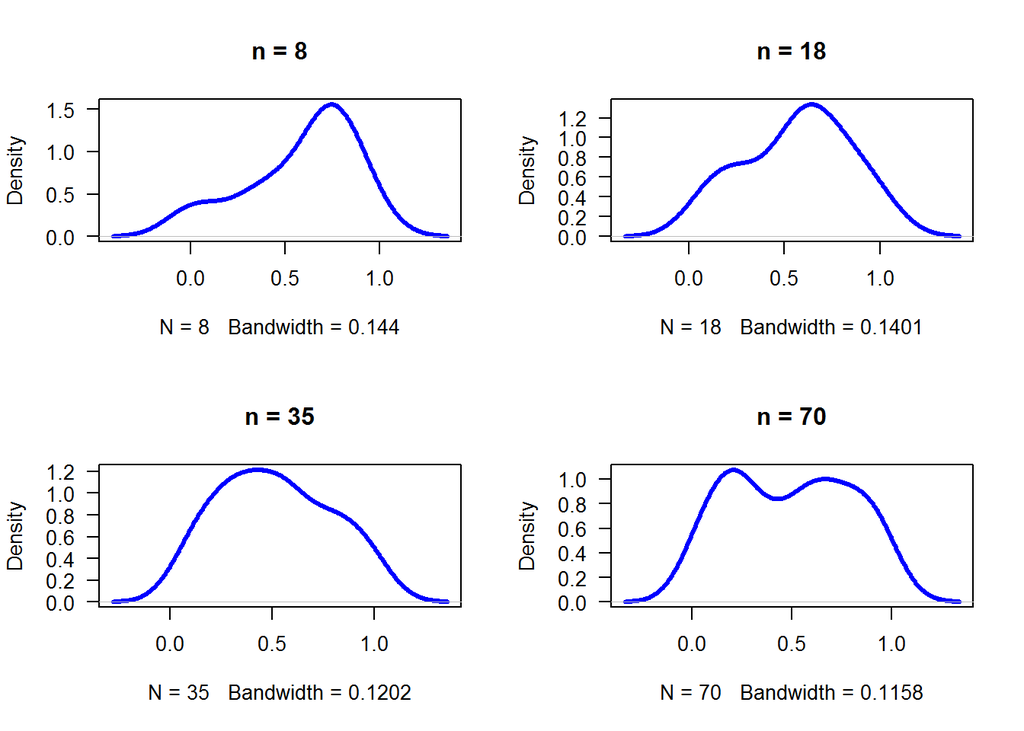

#### **gęstości rozkładu wykładniczego**

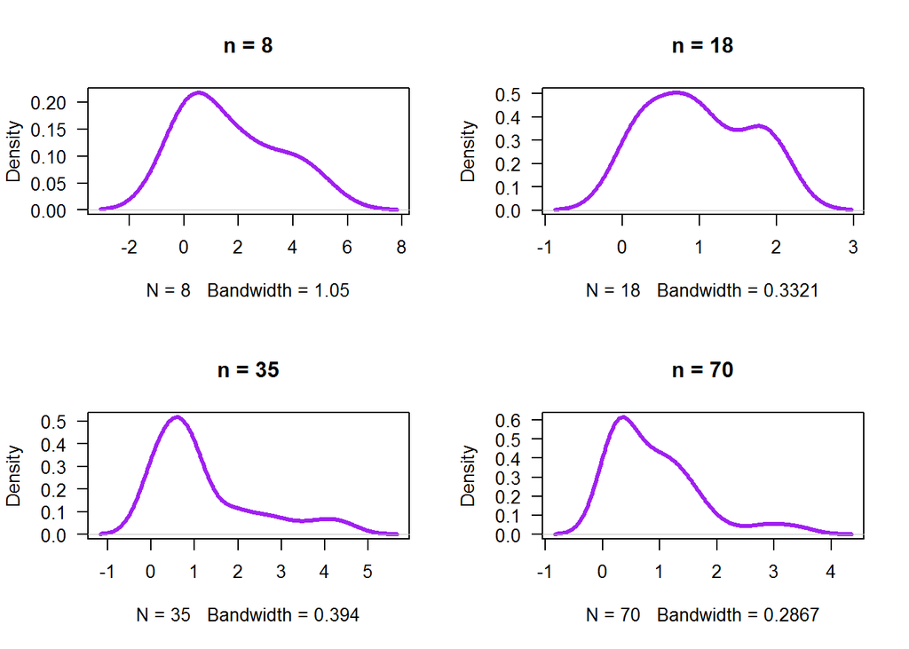

### 1.2 Hipotezy badawcze

Biorąc pod uwagę informacje o testach i wykresy gęstości stawiam następujące hipotezy:

1. Dla małych prób najlepszym testem do badania zgodności z rozkładem normalnym będzie test Shapiro-Wilka.
2. Ze względu na większą czułość w “ogonach”, test Andersona-Darlinga będzie miał dużą moc dla rozkładu t-Studenta i wykładniczego, ze względu na ich specyficzne, rozciągnięte ogony.
3. Ze względu na badanie “ciężko-ogonowości” test SJ sprawdzi się najlepiej dla rozkładu t-Studenta.
4. Moc testu będzie rosła wraz ze wzrostem długości próby ze względu na coraz mniejszy błąd losowy (populacja-próba).
5. Test Jarque-Bera będzie miał dużą moc dla dużych prób z rozkładu t-Studenta oraz wykładniczego, ponieważ bazuje on na momentach z próby, a w tym przypadku rozkład wygląda na leptokurtyczny i w rozkładzie wykładniczym można zauważyć skośność prawostronną.
6. Dla rozkładu jednostajnego moc testów zgodności Jargue-Bera i SJ będzie najmniejsza, ze względu na to, że jest najbardziej symetryczny i ma łagodne ogony, podobne do rozkładu normalnego.

Do zbadania mocy testów użyta została poniższa funkcja:

```r
power <- function(tests, distributions, N=1000, alpha=0.05, n)
{
  eval(parse(text = paste0("test <- ", tests, ".test")))
  eval(parse(text = paste0("dist <- r", distributions)))

  data_frame <- data.frame(rep(NA,N))
    for (j in 1:N){
    if (distributions == "t")
      a <- do.call(dist, list(n,2))
    else
      a <- do.call(dist, list(n))
    b <- do.call(test, list(a))
    data_frame[j,1] <- b$p.value
    }
    powr <- data_frame[which(data_frame < alpha),1]

    return(length(powr)/N)
}
```

Na potrzeby badania został przyjęty poziom istotności = 0.05 oraz wektor długości próby = c(8, 18, 35, 70).  
Moc jest wyznaczona na bazie 1 000 powtórzeń.

### 1.3 Przeprowadzenie badania

#### 1.3.1 Wyniki testów w zależności od długości próby dla każdego z rozkładów:

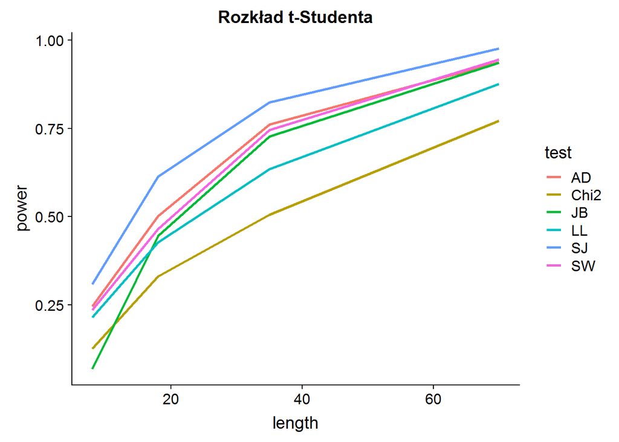

W przypadku każdego testu moc rośnie wraz ze wzrostem długości próby. Najlepiej prezentuje się test SJ, który dla wszystkich badanych liczebności największą moc. Test Jarque-Bera na początku jest najsłabszy, ale jego moc rośnie najszybciej i przy 35 obserwacjach jest już tak samo dobra jak w przypadku testu Sahpiro-Wilka oraz Andersona-Darlinga. Dla tego rozkładu najgorzej wypada test Chi2.

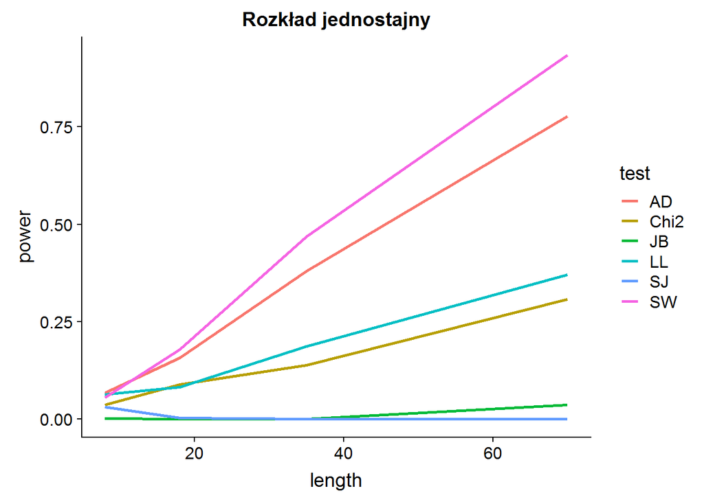

W większości testów moc rośnie razem z długością próby, jednak ten wzrost jest powolny. Wyjątkiem jest test SJ, który jako jedyny maleje i przy 18 obserwacjach spada do 0. Test Jarque-Bera rośnie najwolniej, gdyż dopiero przy około 40 obserwacjach można zauważyć “odbicie się” od 0. Najlepiej wypada test Shapiro-Wilka i Andersona-Darlinga.

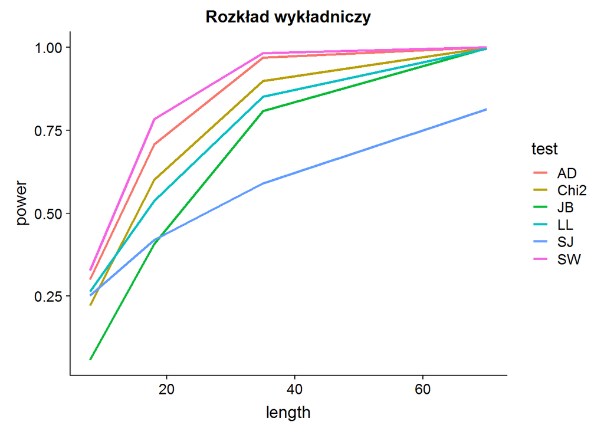

Moce testów rosną bardzo szybko, najlepiej wypada test Shapiro-Wilka, który już przy 35 obserwacjach osiąga 100% moc. Dla 70 obserwacji każdy test ma wartość 1, poza testem SJ, który w tym przypadku rośnie najwolniej.

#### 1.3.2 Wyniki testów w zależności od rozkładu badanej cechy:

Wykresy przedstawiają sumę mocy wszystkich testów z rozróżnieniem na to jaką częścią sumy jest moc danego testu.

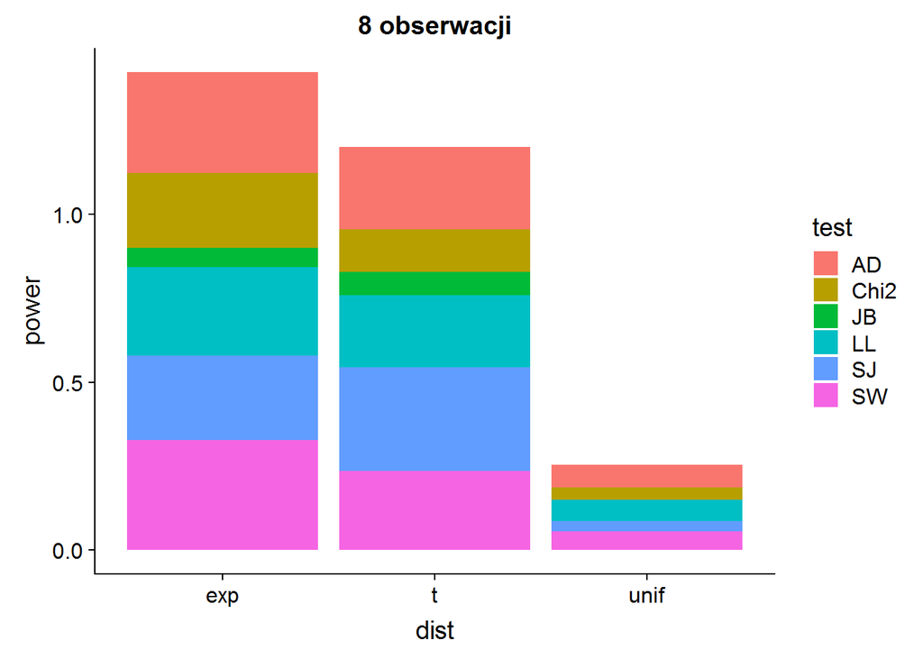

Przy 8 obserwacjach nie można spodziewać się dużych mocy testów, ponieważ jest zbyt duże prawdopodobieństwo błędu losowego. Widzimy, że suma wszystkich 6 testów jest niewiele większa od 1. Najlepsze dla małych obserwacji są testy Shapiro-Wilka oraz Andersona-Darlinga. Najgorzej wypada test Jarque-Bera, który dla rozkładu jednostajnego nawet nie pojawia się na histogramie, gdyż jego moc jest równa 0.

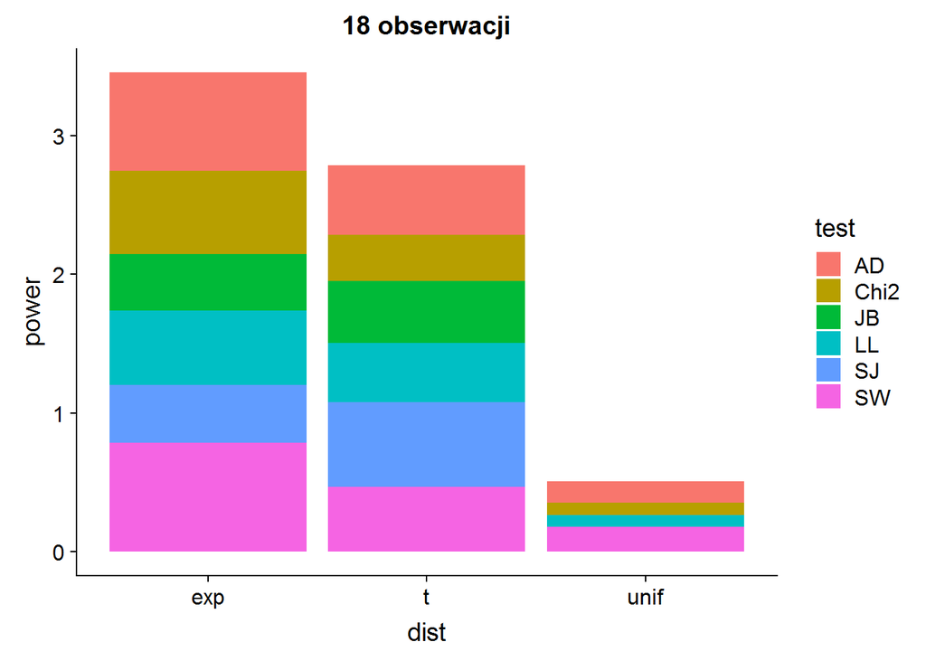

Dla 18 obserwacji widać jak moce testów dla rozkładu jednostajnego odbiegają od reszty rozkładów. Można zauważyć także znaczny wzrost mocy testu Jarque-Bera dla rozkładu wykładniczego oraz t-Studenta, który dla rozkładu jednostajnego w dalszym ciągu ma moc równą 0.

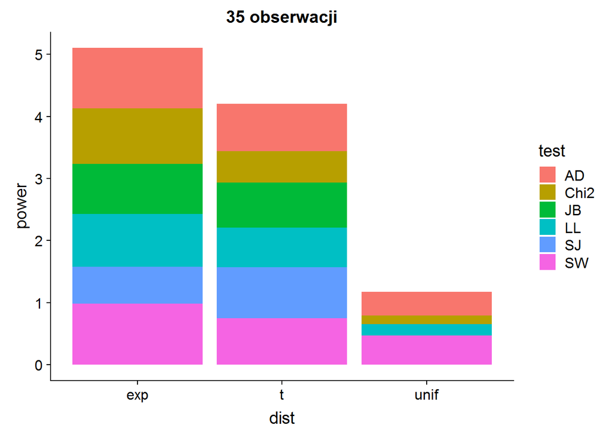

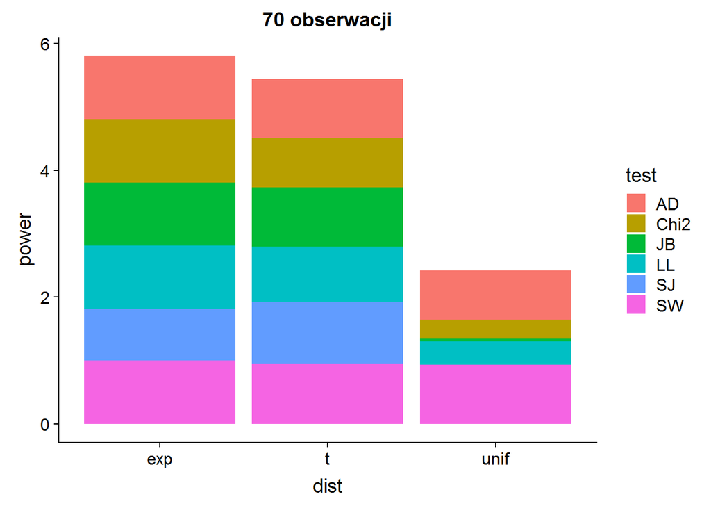

### 1.4 Wnioski

- Moc testu rośnie wraz ze wzrostem próby, poza testem SJ dla rozkładu jednostajnego, dla którego zmalała do 0.
- Test Shapiro-Wilka jest najlepszy dla rozkładu jednostajnego i wykładniczego, dla rozkładu t-Studenta również ma dużą moc, a ponadto jest jednym z najmocniejszych testów w przypadku małej próbki. Jest więc testem, po który z pewnością można sięgać, jeżeli nie ma się wiedzy na temat specyfikacji poszczególnych testów.
- Test Jarque-Bera jest najsłabszym testem dla małych prób. Dla rozkładu wykładniczego oraz t-Studenta radzi sobie bardzo dobrze, ale dopiero przy większych próbach. Jest testem, którego moc rośnie najszybciej wraz ze wzrostem długości próby. Ma słabą moc dla rozkładu jednostajnego, być może dlatego, że rozkład jednostajny jest najbardziej symetryczny(ma skośność w okolicy 0, podobnie jak rozkład normalny), a test Jarque-Bera opiera się o momenty z próby. Jednak przy ok. 30 obserwacjach jego moc zaczyna powoli rosnąć.
- Test Pearsona najlepiej sprawdza się dla rozkładu wykładniczego oraz dla większej próby. Nie warto go stosować dla rozkładu t-Studenta oraz jednostajnego, gdyż są lepsze testy dla tych rozkładów.
- Test Andersona-Darlinga po teście Shapiro-Wilka jest drugim najmocniejszym testem. Dla małych obserwacji sprawdza się równie dobrze. Dobrze rozpoznaje rozkład jednostajny, być może ze względu na jego czułość w ogonach, dzięki czemu rozpoznaje nawet niewielkie różnice. Z pewnością można go spokojnie stosować dla każdego z badanych rozkładów.
- Test Lilieforsa jest dobry, choć nie wyróżnia się jakoś specjalnie na tle innych testów. Dla dużej próby(70 obserwacji) w rozkładzie wykładniczym jest równie skuteczny co reszta testów, z wyjątkiem SJ.
- Test SJ jest najlepszym testem do badania zgodności z rozkładem normalnym dla rozkładu t-Studenta, ponieważ bada ciężko-ogonowość rozkładu, a w rozkładzie t-Studenta ona występuje. Z tego powodu ma słabą moc w przypadku rozkładu jednostajnego, który ma łagodne ogony, zbliżone do ogonów rozkładu normalnego.

# **2. ANOVA**

### 2.1 Wstęp i przedstawienie danych

Analiza wariancji pozwala na zbadanie wpływu danych jakościowych na zmienną ilościową lub przedziałową. Dzięki ANOVIE wieloczynnikowej mamy możliwość sprawdzenia efektu interakcji - jednoczesnego wpływu kilku czynników na zmienną objaśnianą.  
Celem mojej analizy będzie przeprowadzenie ANOVY dla cen mieszkań we Wrocławiu w zależności od:

- liczby pokoi(1-4),
- dzielnicy, w której się znajduje mieszkanie(Krzyki, Śródmieście, Biskupin),
- typu budynku(kamienica, wieżowiec, niski blok).

Hipotezą zerową ANOVY jest równość średnich w podgrupach, więc za hipotezę alternatywną przyjmuję, że średnie różnią się istotnie.  
W przypadku odrzucenia hipotezy zerowej zbadam za pomocą testów post-hoc, które średnie różnią się między sobą. A dzięki badaniu siły efektów eksperymentalnych sprawdzę w jakim stopniu analiza wariancji objaśnia zachodzące zależności.

Poniżej przedstawiam wykresy pudełkowe dla poszczególnych czynników:

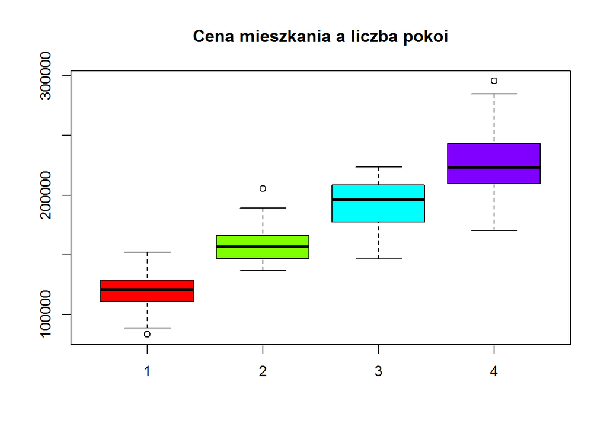

Wykres przedstawiający zależność ceny mieszkania od liczby pokoi sugeruje, że cena będzie rosła wraz ze wzrostem liczby pokoi w mieszkaniu. Jednak biorąc pod uwagę rozproszenie danych może się okazać, że np. za mieszkanie 2-pokojowe trzeba będzie zapłacić więcej niż za mieszaknie 4-pokojowe. Podejrzewam, że różnice będą wynikały z dzielnicy lub typu budynku, w którym znajduje się mieszkanie.

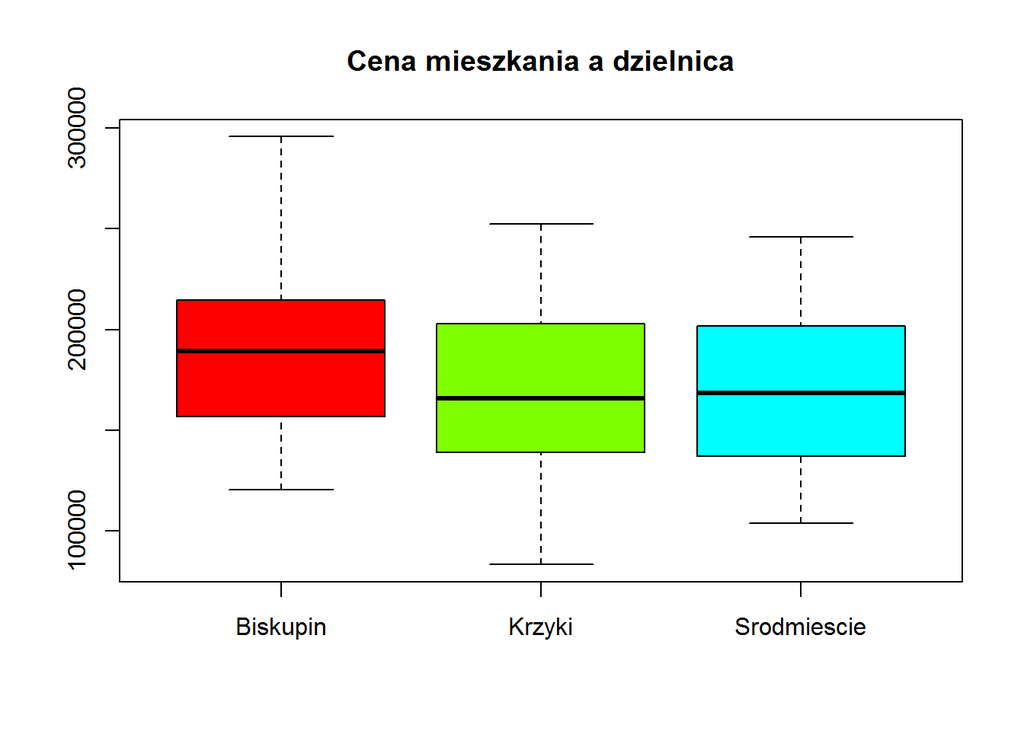

Na podstawie wykresu zależności ceny od dzielnicy widzimy, że w dzielnicy Biskupin ceny mieszkań są największe, a maksymalna cena sięga blisko 300 000zł. W dzielnicy Krzyki i Sródmieście ceny wyglądają podobnie, jednak w Sródmieściu można zauważyć mniejsze rozproszenie cen.

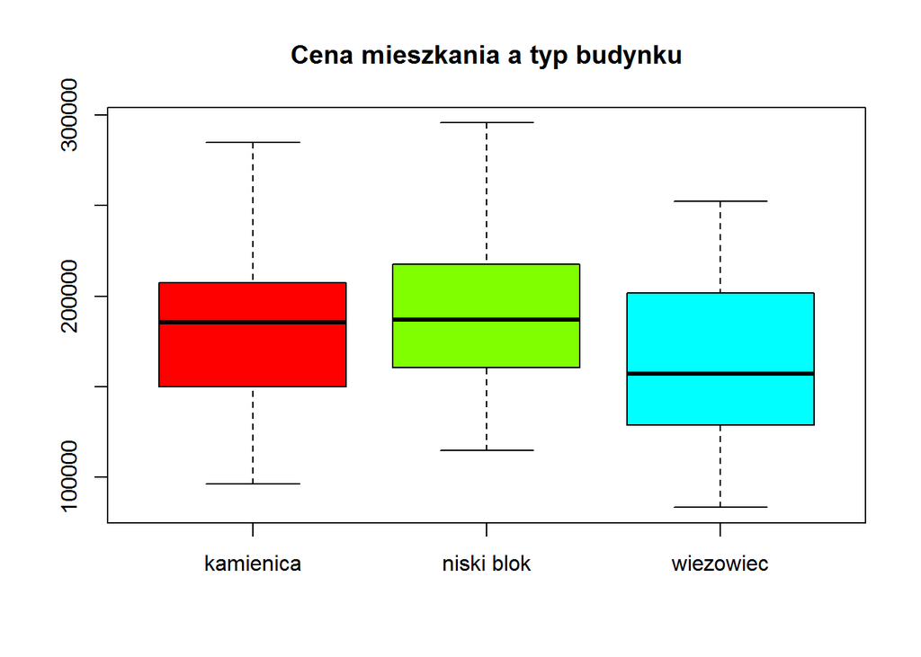

Wykres zależności cen od typu budynku pokazuje, że najtańsze są mieszaknia w wieżowcu, a najdroższe w niskim bloku.

Spójrzmy jeszcze na wykresy średnich w poszczególnych grupach:

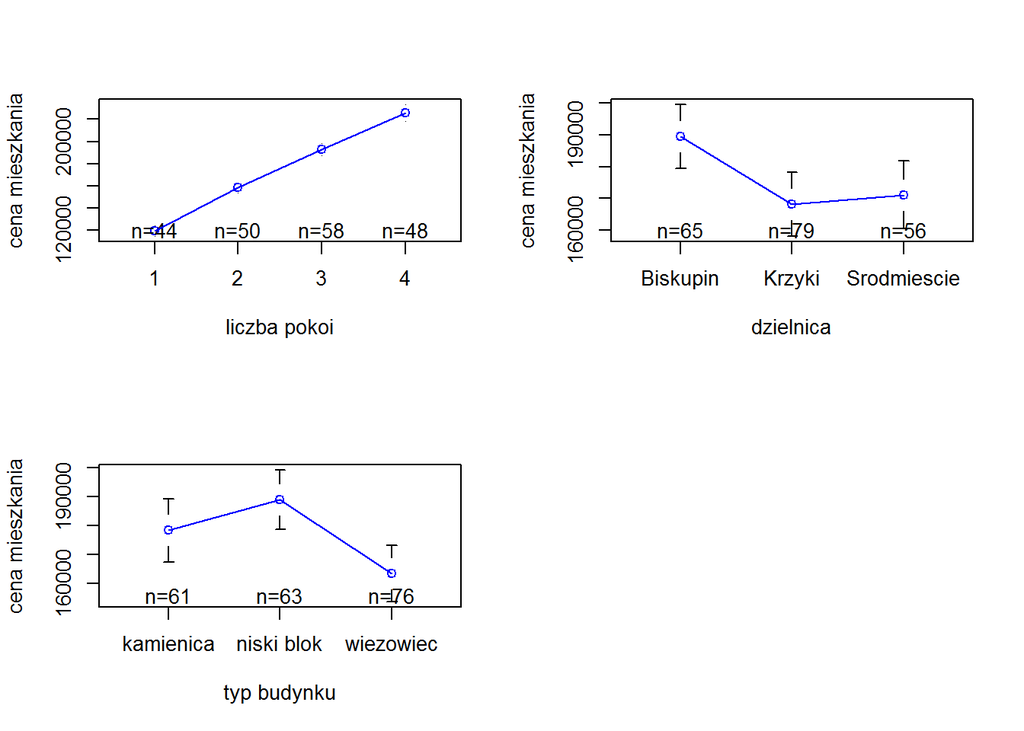

Wygląda na to, że w każdym przypadku średnie różnią się istotnie. Najmniejsza różnica w średnich występuje między dzielnicą Krzyki a dzielnicą Śródmieście.

Zobaczmy także, czy dane sugerują istnienie efektu interakcji pomiędzy zmiennymi:

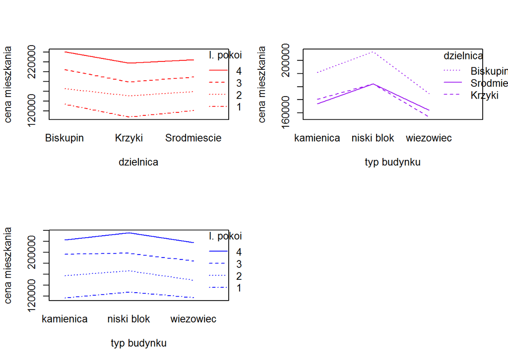

### 2.3 Przeprowadzenie badania

#### 2.3.1 Wyniki ANOVY 3-czynnikowej dla danych dotyczących mieszkań:

```
##                             czynniki      p_value
## 1                           l. pokoi 5.376654e-79
## 2                          dzielnica 6.331887e-13
## 3                        typ budynku 1.570758e-06
## 4               l. pokoi - dzielnica 8.609871e-01
## 5             l. pokoi - typ budynku 4.677593e-01
## 6             dzielnica - typ budyku 6.186440e-02
## 7 l. pokoi - dzielnica - typ budynku 3.335560e-01
```

Przedstawione wyniki świadczą o tym, że średnie ceny w podgrupach dotyczących liczby pokoi, dzielnicy oraz typu budynku różnią się istotnie. Nie pojawił się jednak efekt interakcji na poziomie istotności 0.05. Gdyby przyjąć za poziom istotności 0.1 to możnaby rozważyć jeszcze jednoczesny wpływ dzielnicy i typu budynku. Jednak w celu potwierdzenia wiarygodności ANOVY sprawdzę, czy jej założenia są spełnione.

#### 2.3.2 Założenia ANOVY

1. Zmienna zależna ma wartości na skali przedziałowej.
2. Próbka została wybrana z populacji w sposób losowy.
3. Elementy próby zostały przypisane do danych podgrup losowo.
4. Wszystkie pomiary są niezależne.
5. Dane w każdej próbie mają rozkład normalny.
6. Wariancje w podgrupach są równe.

Zmienną zależną jest cena mieszkania, więc z pewnością ma ona wartości na skali przedziałowej.  
Zakładam, że próbki zostały wybrane z populacji losowo, losowo są przypisane do danych podgrup i wszystkie wymiary są niezależne w związku z obiektywnym charakterem zmiennych.  
Aby przekonać się, czy jest sens badać normalność każdej z podgrup, srawdzę ile każda z nich posiada obserwacji. Jeżeli liczba obserwacji będzie mniejsza od 15, wynik testu normalności może być niedokładny, co potwierdza powyższa analiza mocy testów normalności. W takim wypadku sprawdzę czy reszty mają rozkład normalny.

```
## , , typ budynku = kamienica
##
##      dzielnica
## pokoi Biskupin Krzyki Srodmiescie
##     1        3      4           4
##     2       10      3           4
##     3        9      5           3
##     4        4      9           3
##
## , , typ budynku = niski blok
##
##      dzielnica
## pokoi Biskupin Krzyki Srodmiescie
##     1        2      3           4
##     2        3      8           7
##     3        7      6           7
##     4        5      7           4
##
## , , typ budynku = wiezowiec
##
##      dzielnica
## pokoi Biskupin Krzyki Srodmiescie
##     1        7     11           6
##     2        3      8           4
##     3        8      7           6
##     4        4      8           4
```

Jedna z podgrup ma tylko 2 obserwacje, więc ciężko byłoby zastosować do niej test normalności, a z kolei najliczniejsza posiada 11 obserwacji, więc sprawdzę zgodność rozkładu reszt z rozkładem normalnym.

```
##
##  Shapiro-Wilk normality test
##
## data:  x
## W = 0.99566, p-value = 0.8412
```

Reszty pochodzą z rozkładu normalnego, oznacza to, że próbki są pobrane z populacji o rozkładzie normalnym.  
Należy jeszcze sprawdzić, czy wariancje w podgrupach są jednorodne. W tym celu wykonam test Levene’a, który zakłada jednorodność wariancji.

```
## Levene's Test for Homogeneity of Variance (center = median)
##        Df F value  Pr(>F)
## group  35  1.4014 0.08369 .
##       164
## ---
## Signif. codes:  0 '***' 0.001 '**' 0.01 '*' 0.05 '.' 0.1 ' ' 1
```

P-value jest większe od przyjętego poziomu istotności, co świadczy o spełnieniu założenia dotyczącego jednorodności wariancji w podgrupach.

Skoro założenie normalności i jednorodności wariancji w grupach jest spełnione, to nie mam podstaw, by sądzić, że ANOVA nie daje wiarygodnych wyników. Przeprowadzę w takim razie analizę dwuczynnikową dla dzielnicy oraz typu budynku, aby potwierdzić efekt interakcji.

```
##                 czynniki     p_value
## 1              dzielnica 0.006053821
## 2            typ budynku 0.001655674
## 3 dzielnica - typ budyku 0.964994737
```

Tym razem efekt interakcji dzielnicy i typu budynku został wykluczony. W takim razie dalsza analiza przyjmie postać trzech jednoczynnikowych analiz wariancji.

#### 2.3.3 Testy post-hoc

Aby dowiedzieć się, które średnie z czynników grupujących różnią się istotnie, przeprowadzę testy post-hoc. Użyję do tego testu Tukeya.

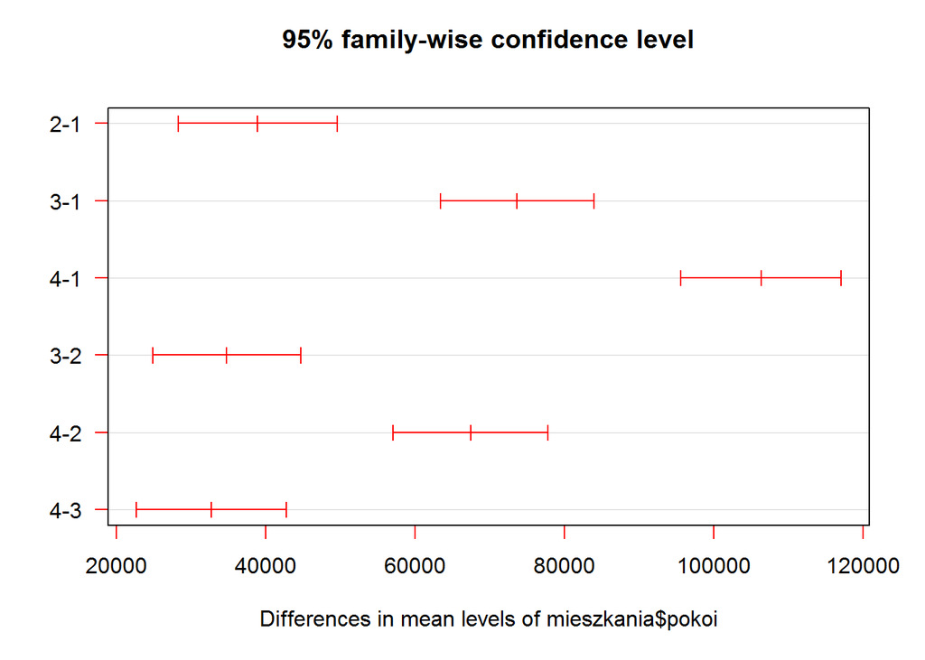

Największa różnica w średnich cen występuje między mieszkaniem 4 a 1-pokojowym. Różnica ta wskazuje, iż mieszkanie 4-pokojowe może być droższe od 1-pokojowego o 95 000 - 120 000 zł. Znacząca różnica jest również między ceną mieszkania 3 a 1-pokojowego (ok. 60 000 - 80 000 zł) oraz między ceną mieszkania 4 a 2-pokojowego (ok. 58 000 - 79 000 zł). Różnice w cenach dla pozostałych kombinacji mieszkań wynoszą mniej więcej 20 000 - 45 000 zł. Wszystkie różnice są istotne.

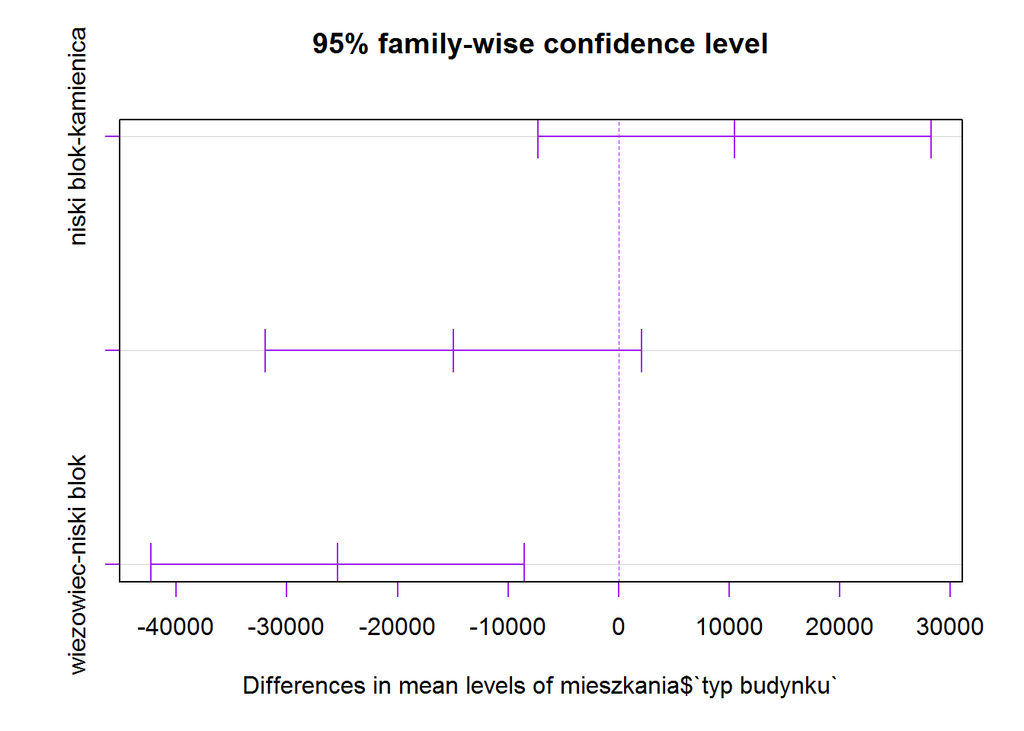

Wykres różnic w średnich cenach dotyczący typu budynku wskazuje, że cena mieszkania w wieżowcu jest o ok. 10 000 - 40 000 zł niższa niż cena mieszkań w niskim bloku, co jest znaczącą różnicą. Różnice w cenach mieszkań w wieżowcu i kamienicy oraz w kamienicy i niskim bloku nie są istotne statystycznie.

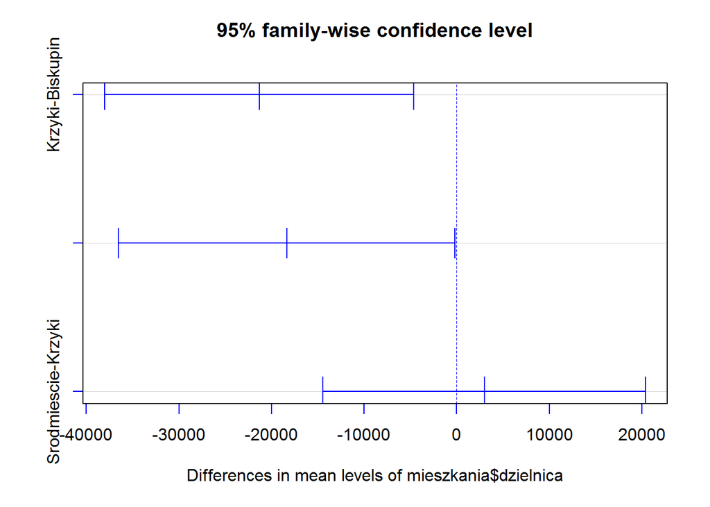

#### 2.3.4 Efekty eksperymentalne

W celu określenia, w jakim stopniu zmienne objaśniające wpływają na wyjaśnienie zmiennej objaśnianej zbadam wielkość efektów eksperymentalnych (eta-kwadrat oraz omega-kwadrat). Eta-kwadrat objaśnia dane pochodzące z próbki, a omega-kwadrat objaśnia dane pochodzące z populacji.

| term | etasq | omegasq |
| --- | --- | --- |
| liczba pokoi | 0.7910639 | 0.7870269 |

Liczba pokoi w mieszkaniu objaśnia ich cenę w 79% w przypadku próbki i w 78.8% w przypadku populacji. Dla tej zmiennej średnie były najbardziej różne od siebie, więc można było się spodziewać największych efektów eksperymentalnych.

| term | etasq | omegasq |
| --- | --- | --- |
| dzielnica | 0.0487286 | 0.0388833 |

Dzielnica, w której znajduje się mieszkanie objaśnia w nieznacznym stopniu jego cenę, gdyż jest to wartość ok. 5% w przypadku próbki i ok. 4% w przypadku populacji. Zważywszy na małą istotność w różnicy średnich (0.006) możemy się spodziewać, że efekty eksperymentalne nie będą spektakularne i w tym przypadku wynoszą jedynie 5%.

| term | etasq | omegasq |
| --- | --- | --- |
| typ budynku | 0.0616587 | 0.0518852 |

Typ budynku także nienajlepiej objaśnia cenę mieszkań, ponieważ w przypadku próbki objaśnione jest ok. 6% danych, a dla populacji 5%. Średnie różnice w cenach mieszkań dla typu budynku również nie są znacząco istotne, co wyjaśnia niski poziom objaśnienia ceny przez typ budynku.

### 2.4 Wnioski

Ceny mieszkań we Wrocławiu zależą w głownej mierze od liczby pokoi, o czym przekonuje w 79% eta-kwadrat w 78.8% omega-kwadrat. Im więcej pokoi jest w mieszkaniu, tym większa jest jego cena, co jest zgodne z postawioną przeze mnie hipotezą.  
Średnie ceny mieszkań w zależności od typu budynku różnią się istotnie tylko w przypadku mieszkania w wieżowcu i w niskim bloku, gdyż mieszkanie w niskim bloku jest droższe od mieszkania w wieżowcu.  
W przypadku dzielnic średnie ceny różnią się najbardziej dla mieszkań w:

- Biskupinie i w Krzykach - mieszkania w Biskupinie są droższe,
- Śródmieściu i Biskupinie - mieszkania w Biskupinie są droższe.